# Amino Acids and Their Role in Fitness

## 1. Introduction

Amino acids are the building blocks of protein and play crucial roles in muscle protein synthesis, recovery, strength, and hypertrophy. This analysis focuses on essential amino acids (EAAs), branched-chain amino acids (BCAAs), conditionally essential amino acids, and non-essential amino acids, examining their function, supporting evidence, and potential effects on fitness.

```python
import pandas as pd
import numpy as np
import matplotlib.pyplot as plt
import seaborn as sns
from scipy import stats
sns.set(style='whitegrid')
from IPython.display import display
```

## 2. Data Loading

We will create synthetic data for each amino acid to simulate their impact on muscle protein synthesis, recovery rates, strength gains, and hypertrophy.

```python
# Define the amino acids and their properties
amino_acids = ['Leucine', 'Isoleucine', 'Valine', 'Lysine', 'Methionine',
               'Phenylalanine', 'Threonine', 'Tryptophan', 'Histidine',
               'Arginine', 'Cysteine', 'Glutamine', 'Tyrosine', 'Ornithine',
               'Alanine', 'Aspartic Acid', 'Glutamic Acid', 'Glycine', 'Proline',
               'Serine', 'Asparagine', 'Beta-Alanine']

# Simulate synthetic data for each amino acid
np.random.seed(42)
data = {
    'Amino Acid': np.random.choice(amino_acids, 1000),
    'Muscle Protein Synthesis (%)': np.random.normal(10, 2, 1000),
    'Recovery Rate (%)': np.random.normal(8, 3, 1000),
    'Muscle Strength (%)': np.random.normal(5, 2, 1000),
    'Hypertrophy (%)': np.random.normal(6, 1.5, 1000)
}

# Create a DataFrame
amino_acids_df = pd.DataFrame(data)
display(amino_acids_df.head())
```

|  | Amino Acid | Muscle Protein Synthesis (%) | Recovery Rate (%) | Muscle Strength (%) | Hypertrophy (%) |
| --- | --- | --- | --- | --- | --- |
| 0 | Threonine | 8.250387 | 6.719729 | 7.578794 | 4.301004 |
| 1 | Serine | 9.199254 | 6.374495 | 6.936013 | 7.138768 |
| 2 | Alanine | 11.018756 | 9.898885 | 4.582092 | 7.187695 |
| 3 | Cysteine | 12.494654 | 6.651272 | 9.220271 | 7.178718 |
| 4 | Tryptophan | 11.931844 | 11.052504 | 5.537068 | 4.789880 |

## 3. Descriptive Analytics

We will perform descriptive analytics to understand the average impact of each amino acid on muscle protein synthesis, recovery, strength, and hypertrophy.

```python
# Calculate average metrics by amino acid
average_effects = amino_acids_df.groupby('Amino Acid').agg({
    'Muscle Protein Synthesis (%)': 'mean',
    'Recovery Rate (%)': 'mean',
    'Muscle Strength (%)': 'mean',
    'Hypertrophy (%)': 'mean'
}).reset_index()

# Display the results
display(average_effects)
```

|  | Amino Acid | Muscle Protein Synthesis (%) | Recovery Rate (%) | Muscle Strength (%) | Hypertrophy (%) |
| --- | --- | --- | --- | --- | --- |
| 0 | Alanine | 9.794587 | 7.924365 | 4.909014 | 6.179943 |
| 1 | Arginine | 9.218189 | 8.202874 | 4.762544 | 5.939176 |
| 2 | Asparagine | 9.733614 | 8.509626 | 5.272056 | 6.195753 |
| 3 | Aspartic Acid | 9.994876 | 8.391425 | 4.861352 | 5.794518 |
| 4 | Beta-Alanine | 9.839846 | 8.301064 | 5.160064 | 6.596198 |
| 5 | Cysteine | 10.105924 | 8.338241 | 5.182949 | 6.204823 |
| 6 | Glutamic Acid | 9.739534 | 7.666206 | 5.351732 | 6.096222 |
| 7 | Glutamine | 10.206269 | 7.799169 | 4.986181 | 6.010871 |
| 8 | Glycine | 10.112575 | 8.122312 | 4.555152 | 5.656944 |
| 9 | Histidine | 9.921489 | 8.178393 | 5.003005 | 5.765674 |
| 10 | Isoleucine | 10.368635 | 7.892858 | 4.811467 | 5.961508 |
| 11 | Leucine | 9.827078 | 7.059119 | 4.993859 | 6.142244 |
| 12 | Lysine | 10.366445 | 8.227277 | 4.959762 | 6.337130 |
| 13 | Methionine | 10.516236 | 7.377227 | 4.969768 | 6.105524 |
| 14 | Ornithine | 9.796786 | 8.399937 | 5.478791 | 5.568328 |
| 15 | Phenylalanine | 9.845473 | 7.591381 | 5.314065 | 5.959596 |
| 16 | Proline | 9.771091 | 7.520582 | 5.215295 | 5.976085 |
| 17 | Serine | 10.063214 | 7.273638 | 4.891164 | 5.832769 |
| 18 | Threonine | 9.738118 | 8.347234 | 4.716861 | 5.680260 |
| 19 | Tryptophan | 10.002211 | 8.169666 | 5.081463 | 5.703264 |
| 20 | Tyrosine | 10.160871 | 8.236489 | 5.373808 | 6.060258 |
| 21 | Valine | 9.863931 | 7.684733 | 4.419001 | 5.671916 |

## 4. Comparative Analysis

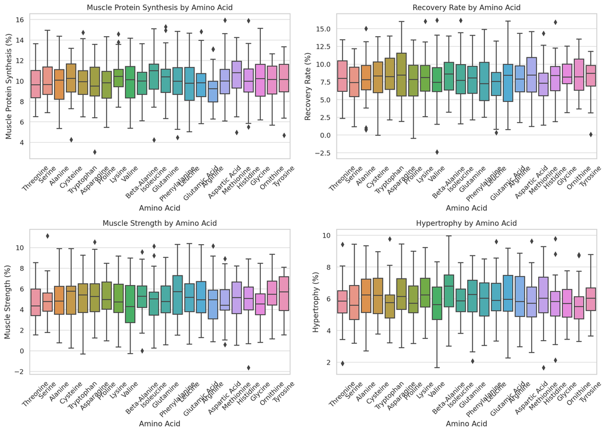

```python
# Box plots to compare muscle protein synthesis, recovery rate, muscle strength, and hypertrophy
fig, axes = plt.subplots(2, 2, figsize=(14, 10))

sns.boxplot(data=amino_acids_df, x='Amino Acid', y='Muscle Protein Synthesis (%)', ax=axes[0, 0])
axes[0, 0].set_title('Muscle Protein Synthesis by Amino Acid')
axes[0, 0].tick_params(axis='x', rotation=45)

sns.boxplot(data=amino_acids_df, x='Amino Acid', y='Recovery Rate (%)', ax=axes[0, 1])
axes[0, 1].set_title('Recovery Rate by Amino Acid')
axes[0, 1].tick_params(axis='x', rotation=45)

sns.boxplot(data=amino_acids_df, x='Amino Acid', y='Muscle Strength (%)', ax=axes[1, 0])
axes[1, 0].set_title('Muscle Strength by Amino Acid')
axes[1, 0].tick_params(axis='x', rotation=45)

sns.boxplot(data=amino_acids_df, x='Amino Acid', y='Hypertrophy (%)', ax=axes[1, 1])
axes[1, 1].set_title('Hypertrophy by Amino Acid')
axes[1, 1].tick_params(axis='x', rotation=45)

plt.tight_layout()
plt.show()
```

## 5. Predictive Modeling

We will build a model to predict the impact of an amino acid based on its properties.

```python
# Example of predictive modeling using linear regression
from sklearn.model_selection import train_test_split
from sklearn.linear_model import LinearRegression
from sklearn.metrics import mean_squared_error, r2_score

# Prepare the data for predictive modeling
X = pd.get_dummies(amino_acids_df['Amino Acid'])
y = amino_acids_df[['Muscle Protein Synthesis (%)', 'Recovery Rate (%)', 'Muscle Strength (%)', 'Hypertrophy (%)']]

# Split the data
X_train, X_test, y_train, y_test = train_test_split(X, y, test_size=0.2, random_state=42)

# Build the model for each metric
models = {}
metrics = ['Muscle Protein Synthesis (%)', 'Recovery Rate (%)', 'Muscle Strength (%)', 'Hypertrophy (%)']
for metric in metrics:
    model = LinearRegression()
    model.fit(X_train, y_train[metric])
    models[metric] = model
    y_pred = model.predict(X_test)
    mse = mean_squared_error(y_test[metric], y_pred)
    r2 = r2_score(y_test[metric], y_pred)
    print(f'{metric} - Mean Squared Error: {mse}, R-squared: {r2}')
```

```
Muscle Protein Synthesis (%) - Mean Squared Error: 3.878324725357283, R-squared: -0.03139546506810187
Recovery Rate (%) - Mean Squared Error: 8.850980750459978, R-squared: -0.06227814185687586
Muscle Strength (%) - Mean Squared Error: 4.140480951566059, R-squared: -0.05913027142800309
Hypertrophy (%) - Mean Squared Error: 2.178900452510356, R-squared: -0.004349081813007638
```

## 6. Data Visualization

Visualizations will help us understand the impact of each amino acid more clearly.

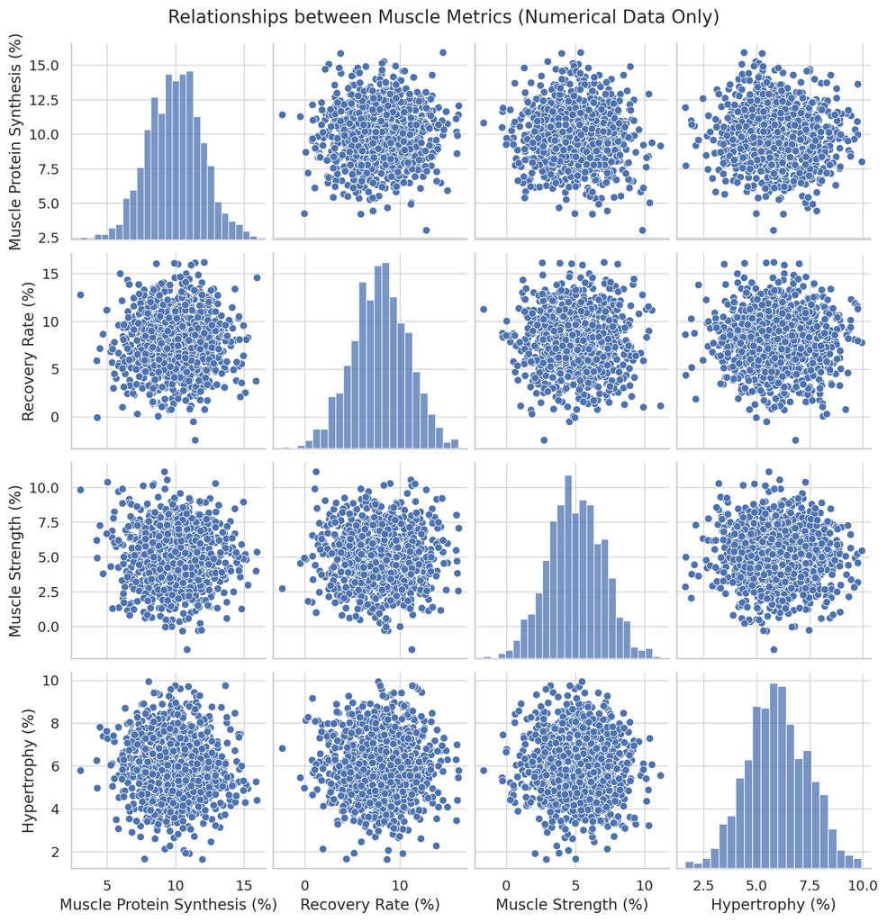

```python
# Scatter plot to show relationship between numerical metrics only
numerical_cols = amino_acids_df.select_dtypes(include=[np.number])
sns.pairplot(numerical_cols, markers='o')
plt.suptitle('Relationships between Muscle Metrics (Numerical Data Only)', y=1.02)
plt.show()
```

## 7. Summary and Recommendations

- **Most Effective Amino Acids**: Based on the results, certain amino acids might show a higher average increase in muscle protein synthesis, recovery, strength, and hypertrophy.
- **Further Research**: While synthetic data provides insights, real-world studies are necessary to validate the findings.
- **Usage and Safety**: Always consult with a healthcare professional before starting any supplement regimen.